# MScA, Bayesian Methods (32014) Week 7 Workshop, Part 2

Y. Balasanov, M.Tselishchev, © iLykei 2016

# 1 References

[G] Andrew Gelman, John B. Carlin, Hal S. Stern, David B. Dunson, Aki Vehtari, Donald B. Rubin, Bayesian Data Analysis, Third Edition, 2013, Taylor & Francis Group.  
[K] John K. Kruschke, Doing Bayesian Data Analysis, A Tutorial with R, JAGS, and STAN, 2015, Elsevier.

# 2 Data

In this example weight of a person in pounds is predicted by height in inches.

For calculation of HDI source the utilities file from [K].

```r
suppressWarnings(source(paste(dataPath,"DBDA2E-utilities.R",sep="/")))
```

```
##
## Kruschke, J. K. (2015). Doing Bayesian Data Analysis, Second Edition:
## A Tutorial with R, JAGS, and Stan. Academic Press / Elsevier.
```

```r
suppressWarnings(library(rstan))
suppressWarnings(library(shinystan))
```

# 3 Simple regression model

The case in this section is a familiar model of the type
$$y=\beta_0+\beta_1 x + \epsilon$$
.

We will see that within Bayesian approach distribution of $\epsilon$ does not have to be Gaussian: we will use robust assumption.

Bayes theorem for this model looks like this:
$$p(\beta_0,\beta_1,\sigma,\gamma|D)=\frac{p(D|\beta_0,\beta_1,\sigma,\gamma)p(\beta_0,\beta_1,\sigma,\gamma)}{\int \int \int \int p(D|\beta_0,\beta_1,\sigma,\gamma)p(\beta_0,\beta_1,\sigma,\gamma)d\beta_0 d\beta_1 d\sigma d\gamma}$$

## 3.1 MCMC in JAGS

Read the data, create the data list.

```r
myData = read.csv( file=paste(dataPath,"HtWtData300.csv",sep="/"))
y <- myData$weight
x = myData$height
dataList = list(
    x = x ,
    y = y
)
```

Describe the model.

```r
 modelString = "
# Standardize the data:
data {
    Ntotal <- length(y)
    xm <- mean(x)
    ym <- mean(y)
    xsd <- sd(x)
    ysd <- sd(y)
    for ( i in 1:length(y) ) {
      zx[i] <- ( x[i] - xm ) / xsd
      zy[i] <- ( y[i] - ym ) / ysd
    }
}
# Specify the model for standardized data:
model {
    for ( i in 1:Ntotal ) {
      zy[i] ~ dt( zbeta0 + zbeta1 * zx[i] , 1/zsigma^2 , nu )
    }
    # Priors vague on standardized scale:
    zbeta0 ~ dnorm( 0 , 1/(10)^2 )
    zbeta1 ~ dnorm( 0 , 1/(10)^2 )
    zsigma ~ dunif( 1.0E-3 , 1.0E+3 )
    nu ~ dexp(1/30.0)
    # Transform to original scale:
    beta1 <- zbeta1 * ysd / xsd
    beta0 <- zbeta0 * ysd  + ym - zbeta1 * xm * ysd / xsd
    sigma <- zsigma * ysd
}
"
  # Write out modelString to a text file
  writeLines( modelString , con="TEMPmodel.txt" )
```

Every arrow has a corresponding line in the description.  
It is also possible putting description of data as

```r
    for ( i in 1:Ntotal ) {
      zy[i] ~ dt( mu[i] , 1/zsigma^2 , nu )
      mu[i]<-zbeta0 + zbeta1 * zx[i]
    }
```

That would allow recording `mu[i]` in MCMC.

Variable names starting with “z” mean that these variables are standardized (z-scores).  
The intention of using z-scores in JAGS is to overcome a problem of correlation of the parameters (see correlation between `beta0` and `beta1` below).  
Strong correlation creates thin and long shape on scatter-plot of the variables which makes Gibbs sampling very slow and inefficient.  
HMC implemented in Stan does not have this problem.

```r
parameters = c( "beta0" ,  "beta1" ,  "sigma",
              "zbeta0" , "zbeta1" , "zsigma", "nu" )
adaptSteps = 500  # Number of steps to "tune" the samplers
burnInSteps = 1000
nChains = 4
thinSteps = 1
numSavedSteps=20000
nIter = ceiling( ( numSavedSteps * thinSteps ) / nChains )
jagsModel = jags.model( "TEMPmodel.txt" , data=dataList , #inits=initsList ,
                      n.chains=nChains , n.adapt=adaptSteps )
```

```
## Compiling data graph
##    Initializing
##    Reading data back into data table
##
```

```r
update( jagsModel , n.iter=burnInSteps )
codaSamples = coda.samples( jagsModel , variable.names=parameters ,
                          n.iter=nIter , thin=thinSteps )
```

Explore the MCMC object.

```r
summary(codaSamples)
```

```
##
## Iterations = 1501:6500
## Thinning interval = 1
## Number of chains = 4
## Sample size per chain = 5000
##
## 1. Empirical mean and standard deviation for each variable,
##    plus standard error of the mean:
##
##              Mean       SD  Naive SE Time-series SE
## beta0  -139.90324 27.57191 0.1949628      0.2208427
## beta1     4.46028  0.41270 0.0029182      0.0032792
## nu        5.36488  1.58068 0.0111771      0.0221048
## sigma    23.97908  1.61155 0.0113954      0.0197565
## zbeta0   -0.09638  0.04718 0.0003336      0.0003946
## zbeta1    0.49036  0.04537 0.0003208      0.0003605
## zsigma    0.68371  0.04595 0.0003249      0.0005633
##
## 2. Quantiles for each variable:
##
##             2.5%       25%        50%        75%      97.5%
## beta0  -193.3935 -158.2738 -140.20834 -121.36804 -84.897251
## beta1     3.6399    4.1815    4.46441    4.73896   5.260384
## nu        3.1993    4.2680    5.05358    6.13115   9.319596
## sigma    20.9481   22.8721   23.94006   25.04072  27.262474
## zbeta0   -0.1879   -0.1281   -0.09679   -0.06421  -0.002765
## zbeta1    0.4002    0.4597    0.49082    0.52100   0.578326
## zsigma    0.5973    0.6521    0.68260    0.71398   0.777326
```

```r
#plot(codaSamples) Too many graphs
#autocorr.plot(codaSamples,ask=F)
effectiveSize(codaSamples)
```

```
##     beta0     beta1        nu     sigma    zbeta0    zbeta1    zsigma
## 15718.457 15961.629  5119.706  6664.209 14327.829 15961.629  6664.209
```

```r
#gelman.diag(codaSamples)
#gelman.plot(codaSamples)   These lines return error. Most likely reason: collinearity of parameters
(HDIofChains<-lapply(codaSamples,function(z) cbind(Mu=HDIofMCMC(codaSamples[[1]][,1]),Sd=HDIofMCMC(codaSamples[[1]][,2]))))
```

```
## [[1]]
##              Mu       Sd
## [1,] -191.49205 3.655601
## [2,]  -84.38615 5.262778
##
## [[2]]
##              Mu       Sd
## [1,] -191.49205 3.655601
## [2,]  -84.38615 5.262778
##
## [[3]]
##              Mu       Sd
## [1,] -191.49205 3.655601
## [2,]  -84.38615 5.262778
##
## [[4]]
##              Mu       Sd
## [1,] -191.49205 3.655601
## [2,]  -84.38615 5.262778
```

Look at strong correlation between `beta0` and `beta1` which slows Gibbs sampling down.

```r
head(as.matrix(codaSamples[[1]]))
```

```
##          beta0    beta1       nu    sigma       zbeta0    zbeta1    zsigma
## [1,] -143.0923 4.539442 3.586350 22.35827 -0.037443051 0.4990659 0.6374942
## [2,] -133.4138 4.350112 3.323610 20.79364 -0.119900652 0.4782509 0.5928823
## [3,] -151.6127 4.659531 3.376645 23.77234 -0.053048665 0.5122684 0.6778131
## [4,] -142.3956 4.501857 4.969151 24.35048 -0.088730127 0.4949338 0.6942974
## [5,] -159.2793 4.740175 5.091243 23.95856 -0.118977594 0.5211344 0.6831228
## [6,] -115.9783 4.152914 5.492142 24.13833  0.003923802 0.4565710 0.6882485
```

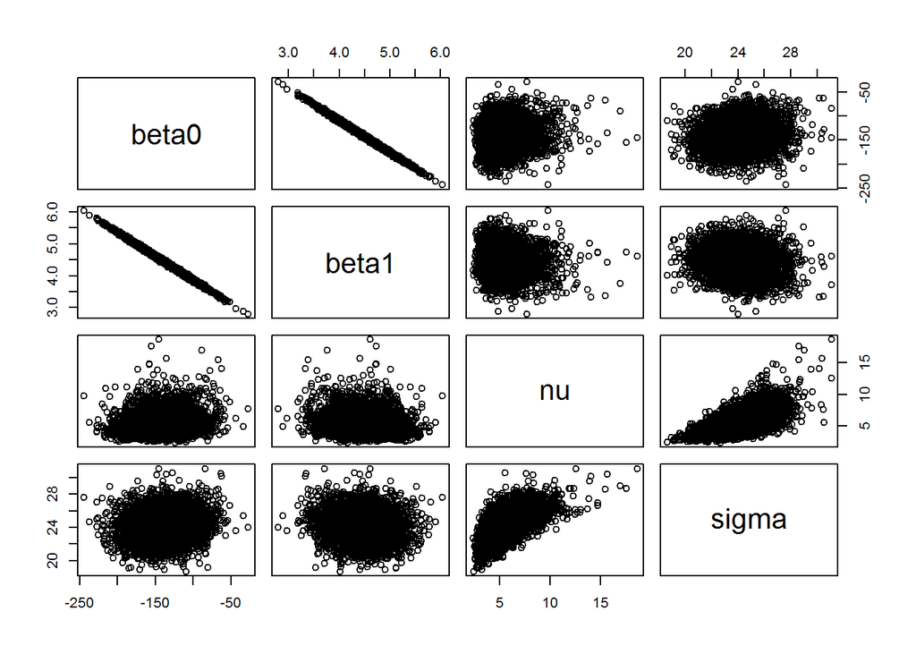

```r
pairs(as.matrix(codaSamples[[1]])[,1:4])
```

## 3.2 MCMC in Stan

Describe the model in Stan.

In order to give a vague priors to slope and intercept consider the following arguments:

1. The largest possible value of slope is
   $$\frac{\sigma_y}{\sigma_x}$$
   when variables $x$ and $y$ are perfectly correlated.
   Then standard deviation of the slope parameter $\beta_1$ should be large enough to make the maximum value easily achievable.
2. Size of intercept is defined by value of
   $$E[X]\frac{\sigma_y}{\sigma_x}$$
   .
   So, the prior should have enough width to include this value.

```r
modelString = "
data {
    int<lower=1> Ntotal;
    real x[Ntotal];
    real y[Ntotal];
    real meanY;
    real sdY;
    real meanX;
    real sdX;
}
transformed data {
    real unifLo;
    real unifHi;
    real expLambda;
    real beta0sigma;
    real beta1sigma;
    unifLo = sdY/1000;
    unifHi = sdY*1000;
    expLambda = 1/30.0;
    beta1sigma = 10*fabs(sdY/sdX);
    beta0sigma = 10*(sdY^2+sdX^2)    / 10*fabs(meanX*sdY/sdX);
}
parameters {
    real beta0;
    real beta1;
    real<lower=0> nu;
    real<lower=0> sigma;
}
model {
    sigma ~ uniform(unifLo, unifHi);
    nu ~ exponential(expLambda);
    beta0 ~ normal(0, beta0sigma);
    beta1 ~ normal(0, beta1sigma);
    for (i in 1:Ntotal) {
        y[i] ~ student_t(nu, beta0 + beta1 * x[i], sigma);
    }
}
"
```

```r
stanDsoRobustReg <- stan_model( model_code=modelString )
```

[output not shown]

```r
d <- read.csv(paste(dataPath,"HtWtData300.csv",sep="/"))
dat<-list(Ntotal=length(d$weight),y=d$weight,meanY=mean(d$weight),
          sdY=sd(d$weight),x=d$height,meanX=mean(d$height),sdX=sd(d$height))
```

```r
# 17_1: robust model to predict metric variable using metric predictor

# using Height-Weight data from Kruschke
# fit model
fitSimRegStan <- sampling(stanDsoRobustReg,
             data=dat,
             pars=c('beta0', 'beta1', 'nu', 'sigma'),
             iter=5000, chains = 4, cores = 4
)
```

Save the fitted object.

```r
save(fitSimRegStan,file=paste(dataPath,"fitSimRegStan.Rdata",sep="/"))
load(paste(dataPath,"fitSimRegStan.Rdata",sep="/"))
```

```r
print (fitSimRegStan)
```

```
## Inference for Stan model: 99bd7b261ff9240bf0c6d7b1b21831d6.
## 4 chains, each with iter=5000; warmup=2500; thin=1;
## post-warmup draws per chain=2500, total post-warmup draws=10000.
##
##           mean se_mean    sd     2.5%      25%      50%      75%    97.5%
## beta0  -140.39    0.50 27.95  -194.47  -159.14  -140.76  -121.98   -85.11
## beta1     4.47    0.01  0.42     3.64     4.19     4.47     4.75     5.28
## nu        5.38    0.03  1.65     3.13     4.26     5.05     6.12     9.51
## sigma    23.97    0.03  1.65    20.85    22.85    23.94    25.02    27.38
## lp__  -1265.00    0.03  1.51 -1268.75 -1265.69 -1264.64 -1263.90 -1263.18
##       n_eff Rhat
## beta0  3084    1
## beta1  3109    1
## nu     3239    1
## sigma  3620    1
## lp__   3003    1
##
## Samples were drawn using NUTS(diag_e) at Wed May 09 14:41:42 2018.
## For each parameter, n_eff is a crude measure of effective sample size,
## and Rhat is the potential scale reduction factor on split chains (at
## convergence, Rhat=1).
```

```
## ci_level: 0.8 (80% intervals)
```

```
## outer_level: 0.95 (95% intervals)
```

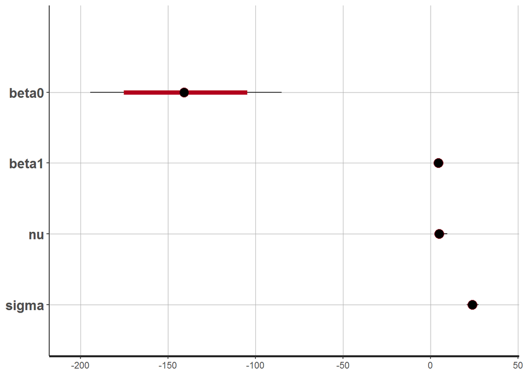

```r
plot(fitSimRegStan)
```

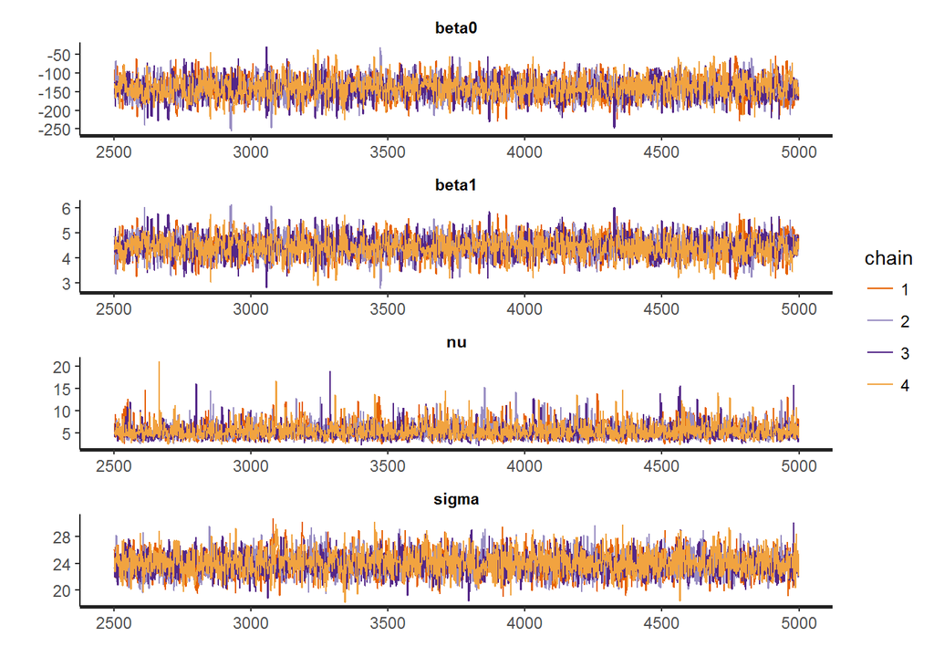

```r
rstan::traceplot(fitSimRegStan, ncol=1, inc_warmup=F)
```

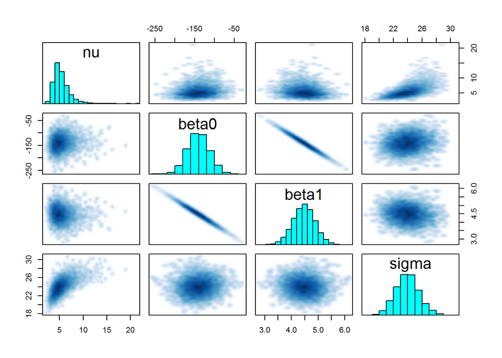

```r
pairs(fitSimRegStan, pars=c('nu','beta0','beta1','sigma'))
```

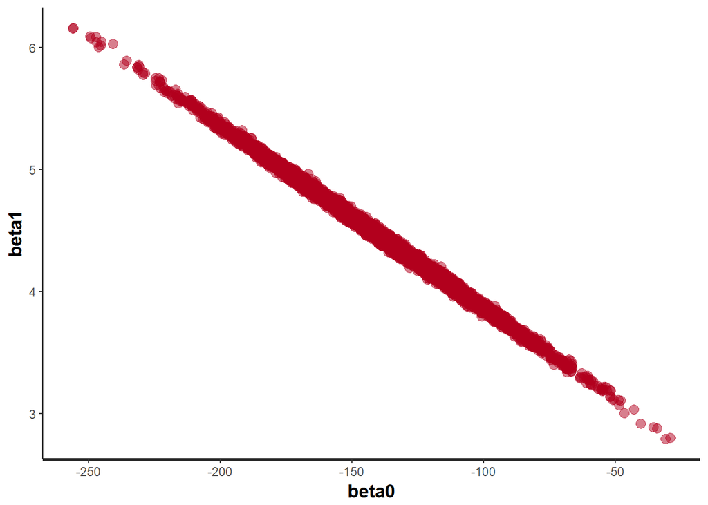

```r
stan_scat(fitSimRegStan, c('beta0','beta1'))
```

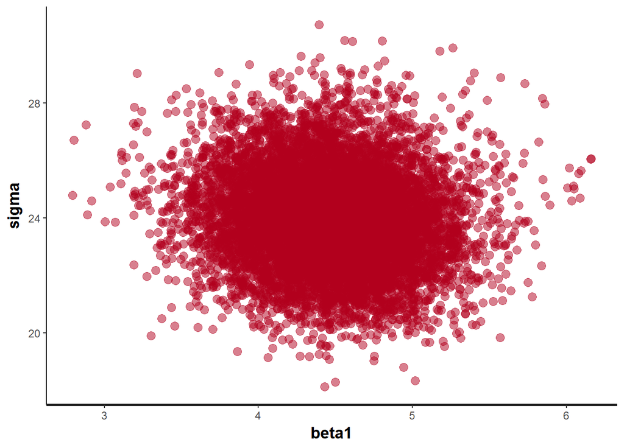

```r
stan_scat(fitSimRegStan, c('beta1','sigma'))
```

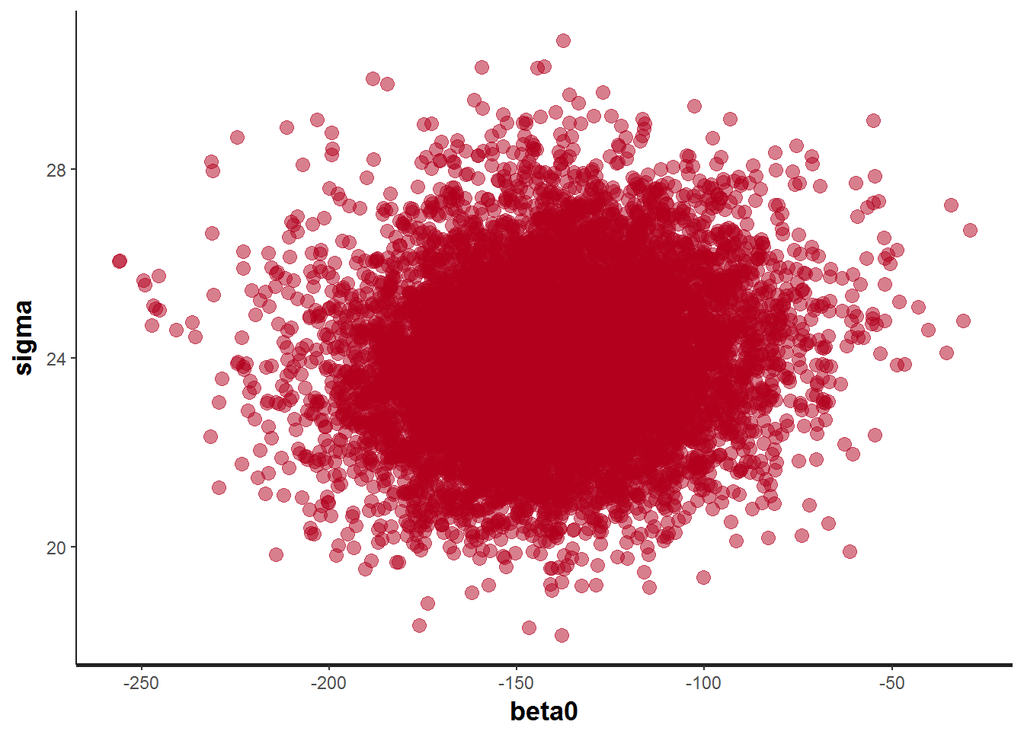

```r
stan_scat(fitSimRegStan, c('beta0','sigma'))
```

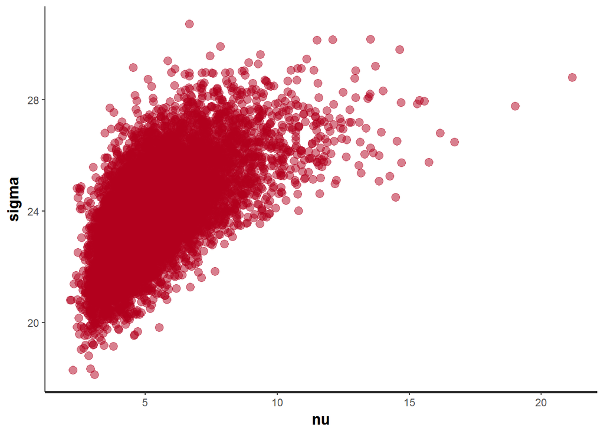

```r
stan_scat(fitSimRegStan, c('nu','sigma'))
```

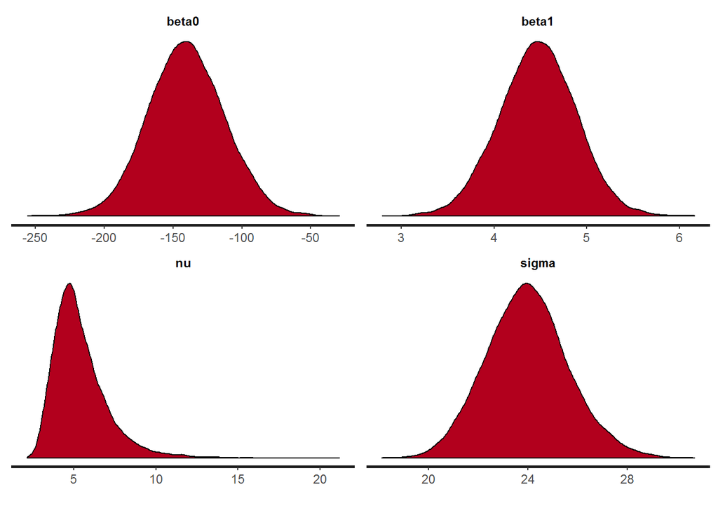

```r
stan_dens(fitSimRegStan)
```

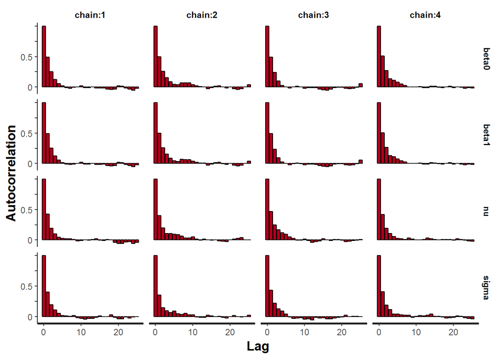

```r
stan_ac(fitSimRegStan, separate_chains = T)
```

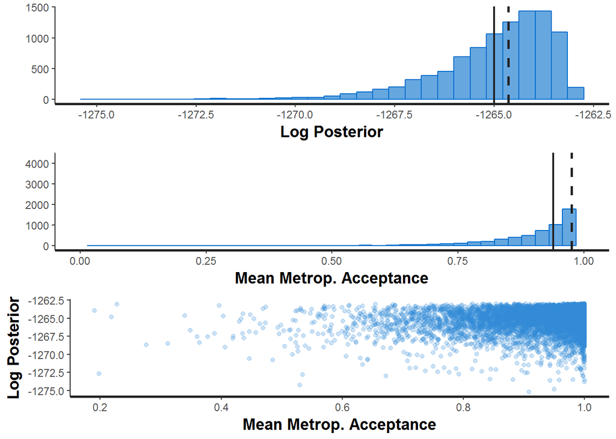

```r
stan_diag(fitSimRegStan,information = "sample",chain=0)
```

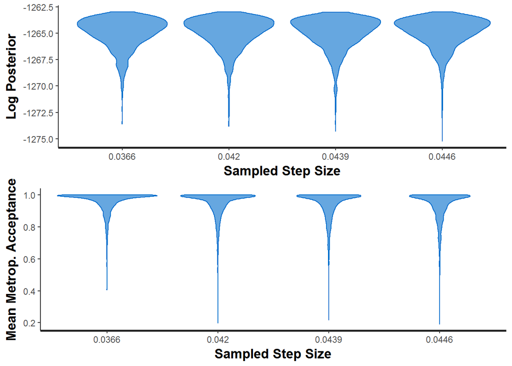

```r
stan_diag(fitSimRegStan,information = "stepsize",chain = 0)
```

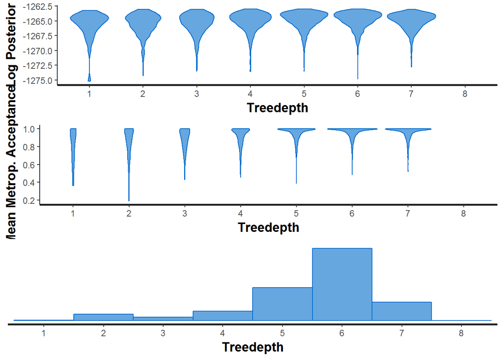

```r
stan_diag(fitSimRegStan,information = "treedepth",chain = 0)
```

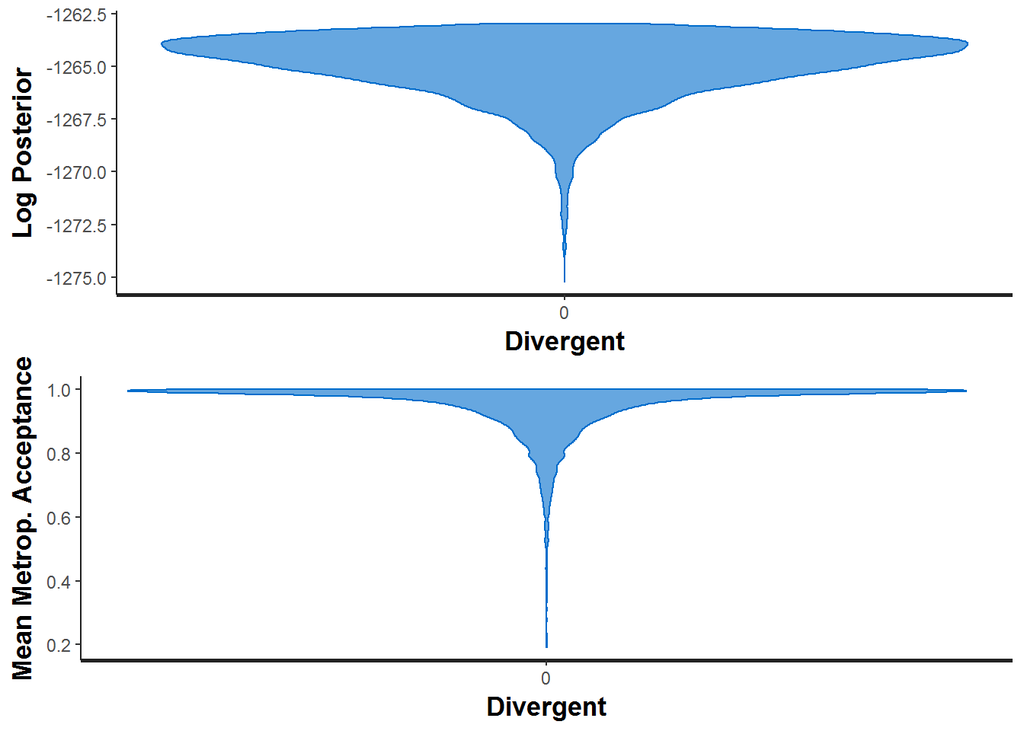

```r
stan_diag(fitSimRegStan,information = "divergence",chain = 0)
```

Work with shinystan object.

```r
launch_shinystan(fitSimRegStan)
```

# 4 Using fitted regression model for prediction

Recall that the data in this example contains predictor height and output weight for a group of people from `HtWtData300.csv`.

Plot all heights observed in the sample and check the summary of the variable.

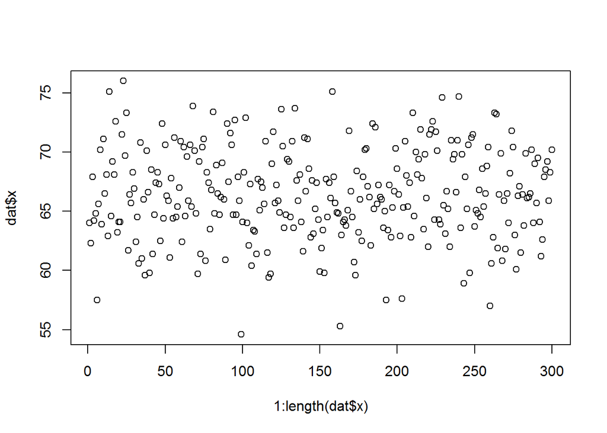

```r
plot(1:length(dat$x),dat$x)
```

```r
summary(dat$x)
```

```
##    Min. 1st Qu.  Median    Mean 3rd Qu.    Max.
##   54.60   64.00   66.20   66.39   69.20   76.00
```

Can we predict weight of a person who is 50 or 80 inches tall?

To do this we can go through all pairs of simulated parameters $(\beta_0,\beta_1)$ and use them to simulate $y(50)$ and $y(80)$.  
This gives distribution of predicted values.

```r
summary(fitSimRegStan)
```

```
## $summary
##               mean     se_mean         sd         2.5%          25%
## beta0  -140.391333 0.503326497 27.9519414  -194.469811  -159.135368
## beta1     4.467926 0.007506671  0.4185661     3.638691     4.193589
## nu        5.375571 0.029074454  1.6546324     3.128614     4.264379
## sigma    23.972077 0.027375571  1.6471601    20.849695    22.847712
## lp__  -1264.995981 0.027508443  1.5075188 -1268.745629 -1265.691573
##                50%          75%        97.5%    n_eff     Rhat
## beta0  -140.759600  -121.981065   -85.109573 3084.071 1.002313
## beta1     4.473044     4.748231     5.278839 3109.091 1.002283
## nu        5.048918     6.121381     9.513421 3238.769 1.002153
## sigma    23.940004    25.021941    27.376511 3620.306 1.002735
## lp__  -1264.638522 -1263.901337 -1263.179095 3003.264 1.000914
##
## $c_summary
## , , chains = chain:1
##
##          stats
## parameter         mean         sd         2.5%          25%          50%
##     beta0  -139.917587 27.9664868  -194.258922  -158.473253  -140.773162
##     beta1     4.460894  0.4185821     3.598931     4.183112     4.473953
##     nu        5.334490  1.6502573     3.128061     4.231480     4.983565
##     sigma    23.937167  1.6720808    20.636458    22.876842    23.915673
##     lp__  -1264.999307  1.4777396 -1268.696558 -1265.683564 -1264.653770
##          stats
## parameter          75%        97.5%
##     beta0  -121.473049   -82.979453
##     beta1     4.741489     5.281398
##     nu        6.077693     9.632639
##     sigma    24.974449    27.371846
##     lp__  -1263.925886 -1263.171885
##
## , , chains = chain:2
##
##          stats
## parameter         mean         sd         2.5%          25%          50%
##     beta0  -140.537420 27.9424025  -193.689446  -159.721941  -140.139587
##     beta1     4.470098  0.4188618     3.646558     4.182708     4.465363
##     nu        5.395827  1.5731244     3.149023     4.312535     5.123174
##     sigma    23.968857  1.6135159    20.898233    22.889243    23.926750
```

[output cut: 27 more lines]

```
##
##          stats
## parameter         mean         sd         2.5%          25%          50%
##     beta0  -137.980299 27.4371356  -189.482975  -155.564670  -138.728454
##     beta1     4.432181  0.4104869     3.594831     4.170005     4.441302
##     nu        5.504517  1.7202725     3.165876     4.343326     5.130410
##     sigma    24.132498  1.6925959    20.936554    22.996243    24.081242
##     lp__  -1265.007015  1.5382401 -1268.766287 -1265.734917 -1264.631925
##          stats
## parameter          75%        97.5%
##     beta0  -120.557922   -82.203278
##     beta1     4.696381     5.202383
##     nu        6.266206     9.663362
##     sigma    25.219814    27.518127
##     lp__  -1263.890564 -1263.179138
```

```r
regParam<-cbind(Beta0=rstan::extract(fitSimRegStan,pars="beta0")$'beta0',
                Beta1=rstan::extract(fitSimRegStan,pars="beta1")$'beta1')
head(regParam)
```

```
##          Beta0    Beta1
## [1,] -117.2310 4.180224
## [2,] -132.9951 4.369664
## [3,] -116.7232 4.138217
## [4,] -149.0519 4.632793
## [5,] -135.8293 4.367481
## [6,] -136.0067 4.433407
```

```r
predX50<-apply(regParam,1,function(z) z%*%c(1,50))
predX80<-apply(regParam,1,function(z) z%*%c(1,80))
```

Plot both distributions, look at their summaries and HDIs.

```r
suppressWarnings(library(HDInterval))
```

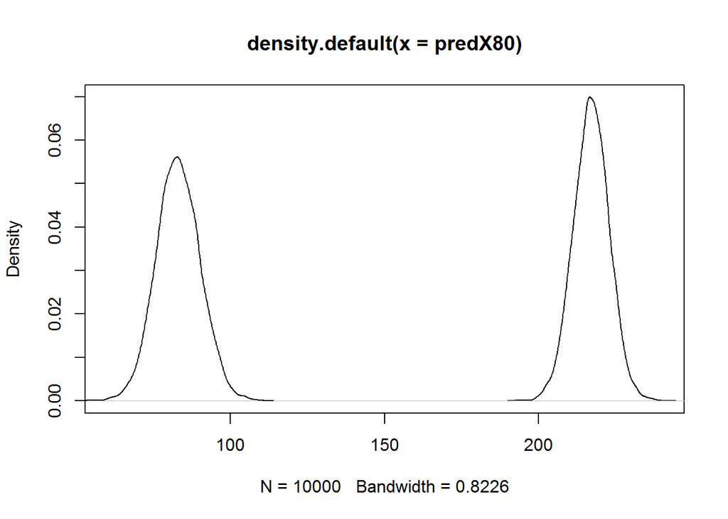

```r
den<-density(predX50)
plot(density(predX80),xlim=c(60,240))
lines(den$x,den$y)
```

```r
summary(cbind(predX50,predX80))
```

```
##     predX50          predX80
##  Min.   : 51.82   Min.   :192.3
##  1st Qu.: 78.23   1st Qu.:213.2
##  Median : 82.90   Median :217.1
##  Mean   : 83.00   Mean   :217.0
##  3rd Qu.: 87.80   3rd Qu.:220.9
##  Max.   :110.83   Max.   :241.9
```

```r
rbind(predX50=hdi(predX50),predX80=hdi(predX80))
```

```
##             lower     upper
## predX50  69.56243  97.42864
## predX80 205.01243 227.83915
```

# 5 Hierarchical regression on individuals within groups

## 5.1 Simulated data from the book

This example is from Section 17.3 of [K].

In section 2 each individual produced one pair $(x_i,y_i)$.  
In panel or longitudinal data each individual, $j$, produces a sequence of obsevations $(x_{1|j},y_{1|j}),\ldots,(x_{n_j|j},y_{n_j|j})$.  
From such data it is possible to estimate regression for each individual $j$: $y_{i|j}=\beta_0[j]+\beta_0[j] x_{i|j}$ and, if there is a reason to believe that individuals represent a group that has a common tendency parameters of that tendency can be estimated also.

**Examples**:

- Children’s reading ability is tested for several years. All children develop reading skills during that period. But each individual child has his or her own learning slopes, while all children as a group may have developmental patterns expressed through higher level patterns
- In a study of how family income varies with size of the family and in different geagraphical regions. The U.S. Census Bureau has publishe median family income as function as of of persons in the family per state. In this study state plays the role of an individual, the oservations for each individual include sample of family sizes and the corresponding incomes.

Data come from Student distribution with mean $\mu_{i|j}=\beta_{0,j}+\beta_{1,j} x_{i|j}$, where index $j$ shows that each individual has own slope and intercept indexed by $j$.

All individual slopes come from a single normal distribution with parameters $(M_1,S_1)$.  
Similarly, all individual intercepts come from a normal distribution with parameters $(M_0,S_0)$.  
Parameters $M_0, S_0, M_1, S_1$ are estimated and have their own uninformative priors.  
All observations have same $\sigma$ with wide uniform pior distribution.  
It is possible to make an individual parameters $\sigma_j$ with joint prior.

### 5.1.1 Data

Read the data.

```r
df = read.csv(file=paste(dataPath,"HierLinRegressData.csv",sep="/"))
head(df)
```

```
##   Subj    X     Y
## 1    1 60.2 145.6
## 2    1 61.5 157.3
## 3    1 61.7 165.6
## 4    1 62.3 158.8
## 5    1 67.6 196.1
## 6    1 69.2 183.9
```

```r
unique(df$Subj)
```

```
##  [1]  1  2  3  4  5  6  7  8  9 10 11 12 13 14 15 16 17 18 19 20 21 22 23
## [24] 24 25
```

```r
summary(df)
```

```
##       Subj             X               Y
##  Min.   : 1.00   Min.   :49.10   Min.   : 70.0
##  1st Qu.: 6.00   1st Qu.:62.50   1st Qu.:131.3
##  Median :12.00   Median :66.25   Median :153.6
##  Mean   :12.13   Mean   :67.08   Mean   :153.3
##  3rd Qu.:18.00   3rd Qu.:71.40   3rd Qu.:172.6
##  Max.   :25.00   Max.   :86.20   Max.   :240.4
```

```r
str(df)
```

```
## 'data.frame':    132 obs. of  3 variables:
##  $ Subj: int  1 1 1 1 1 1 2 2 2 2 ...
##  $ X   : num  60.2 61.5 61.7 62.3 67.6 69.2 53.7 60.1 60.5 62.3 ...
##  $ Y   : num  146 157 166 159 196 ...
```

```r
dataList<-list(Ntotal=length(df$Y),
               y=df$Y,
               x=df$X,
               Ngroups = max(df$Subj),
               group = df$Subj
)
```

### 5.1.2 Model description

Description of the model is in the file “ch17_2.stan”:

```r
modelStringPanel = "
data {
    int<lower=1> Ntotal;
    vector[Ntotal] y;
    vector[Ntotal] x;
    int<lower=1> Ngroups;
    int<lower=1, upper=Ngroups> group[Ntotal];
}
transformed data {
    real meanY;
    real sdY;
    vector[Ntotal] zy; // normalized y
    real meanX;
    real sdX;
    vector[Ntotal] zx; // normalized x
    meanY = mean(y);
    sdY = sd(y);
    zy = (y - meanY) / sdY;
    meanX = mean(x);
    sdX = sd(x);
    zx = (x - meanX) / sdX;
}
parameters {
    real<lower=0> zsigma;
    real<lower=0> nu;
    real zbeta0mu;
    real zbeta1mu;
    real<lower=0> zbeta0sigma;
    real<lower=0> zbeta1sigma;
    vector[Ngroups] zbeta0;
    vector[Ngroups] zbeta1;
}
transformed parameters {
    real<lower=0> sigma;
    real beta0mu;
    real beta1mu;
    vector[Ngroups] beta0;
    vector[Ngroups] beta1;
    // Transform to original scale:
    sigma = zsigma * sdY;
    beta0mu = meanY + zbeta0mu * sdY  - zbeta1mu * meanX * sdY / sdX;
    beta1mu = zbeta1mu * sdY / sdX;
    beta0 = meanY + zbeta0 * sdY  - zbeta1 * meanX * sdY / sdX; // vectorized
    beta1 = zbeta1 * sdY / sdX;                                 // vectorized
}
model {
    zsigma ~ uniform(0.001, 1000);
    nu ~ exponential(1/30.0);
    zbeta0mu ~ normal(0, 10.0^2);
    zbeta1mu ~ normal(0, 10.0^2);
    zbeta0sigma ~ uniform(0.001, 1000);
    zbeta1sigma ~ uniform(0.001, 1000);
    zbeta0 ~ normal(zbeta0mu, zbeta0sigma);  // vectorized
    zbeta1 ~ normal(zbeta1mu, zbeta1sigma);  // vectorized
    for (i in 1:Ntotal) {
        zy[i] ~ student_t(1+nu, zbeta0[group[i]] + zbeta1[group[i]] * x[i], zsigma);
    }
}"
```

### 5.1.3 First run: default parameters

Prepare the model and run MCMC.

```r
# 17_2: robust model to predict grouped metric variable using metric predictor

# prepare DSO model
# 2 alternative ways: from file or from created string.
#stanDsoRobustRegPanel <- stan_model(file=paste(dataPath,
#                                               "BayesStanExamples/ch17/ch17_2.stan",sep="/"));
stanDsoRobustRegPanel <- stan_model( model_code=modelStringPanel )
```

[output not shown]

```r
fit <- sampling (stanDsoRobustRegPanel,
                 data=dataList,
                 pars=c('nu', 'sigma', 'beta0mu', 'beta1mu', 'beta0', 'beta1',
                        'zbeta0sigma', 'zbeta1sigma'),
                 iter=5000,
                 chains = 4, cores = 4
                 )
```

Most likely the run will not be successful: there is a number of divergent transitions after warmup.  
This happens because of collinearity of parameters of intercept and slope at all levels.

Explore the shinystan object.

```r
launch_shinystan(fit)
```

### 5.1.4 Trying to improve convergence by altering step size

Here is a useful [blog post](http://singmann.org/hierarchical-mpt-in-stan-i-dealing-with-convergent-transitions-via-control-arguments/) addressing similar issue.  
It recommends setting parameters controlling step size to shorten steps:

```r
fit <- sampling (model,
                 data=dataList,
                 pars=c('nu', 'sigma', 'beta0mu', 'beta1mu', 'beta0', 'beta1',
                        'zbeta0sigma', 'zbeta1sigma'),
                 iter=50000,
                 chains = 4, cores = 4,
                 control = list(adapt_delta = 0.999, stepsize = 0.01, max_treedepth = 15)
                 )
```

The run with reduced step size is significantly longer.  
Again `n_divergent__` transactions are reported, so, recommended steps did not help.  
Save the fit.

```r
save(fit,file=paste(dataPath,"fitPanelModifControl11152016.Rdata",sep="/"))
load(paste(dataPath,"fitPanelModifControl11152016.Rdata",sep="/"))
```

Check chain parameters:

```r
print (fit)
```

[output not shown]

[output cut: 70 more lines]

```
## beta1[19]     302 1.01
## beta1[20]     291 1.01
## beta1[21]     291 1.01
## beta1[22]     292 1.02
## beta1[23]     299 1.02
## beta1[24]     236 1.01
## beta1[25]     335 1.02
## zbeta0sigma    91 1.04
## zbeta1sigma   183 1.02
## lp__          133 1.03
##
## Samples were drawn using NUTS(diag_e) at Wed May 09 14:43:29 2018.
## For each parameter, n_eff is a crude measure of effective sample size,
## and Rhat is the potential scale reduction factor on split chains (at
## convergence, Rhat=1).
```

Note that parameter $\nu$ is greater than 30, meaning that the distribution is practically Gaussian.

```
## ci_level: 0.8 (80% intervals)
```

```
## outer_level: 0.95 (95% intervals)
```

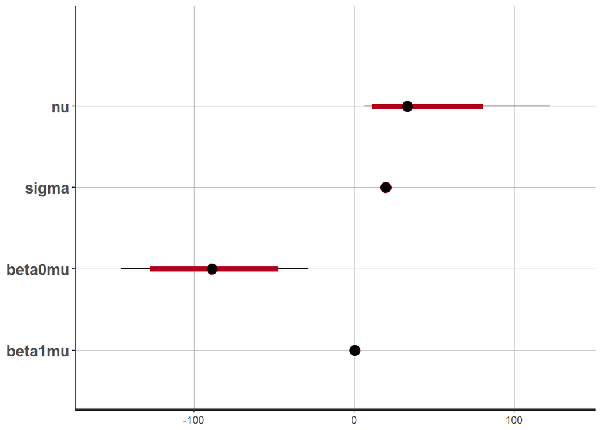

```r
plot(fit,pars=c('nu', 'sigma', 'beta0mu', 'beta1mu'))
```

```
## ci_level: 0.8 (80% intervals)
```

```
## outer_level: 0.95 (95% intervals)
```

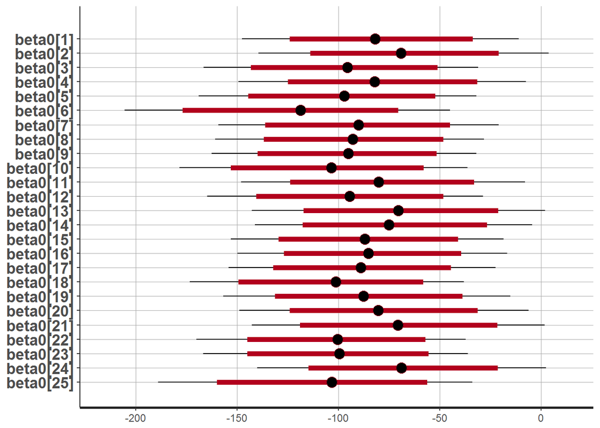

```r
plot(fit,pars=c('beta0'))
```

```
## ci_level: 0.8 (80% intervals)
## outer_level: 0.95 (95% intervals)
```

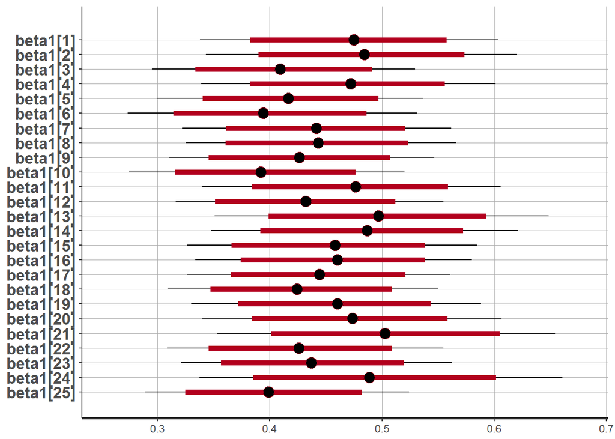

```r
plot(fit,pars=c('beta1'))
```

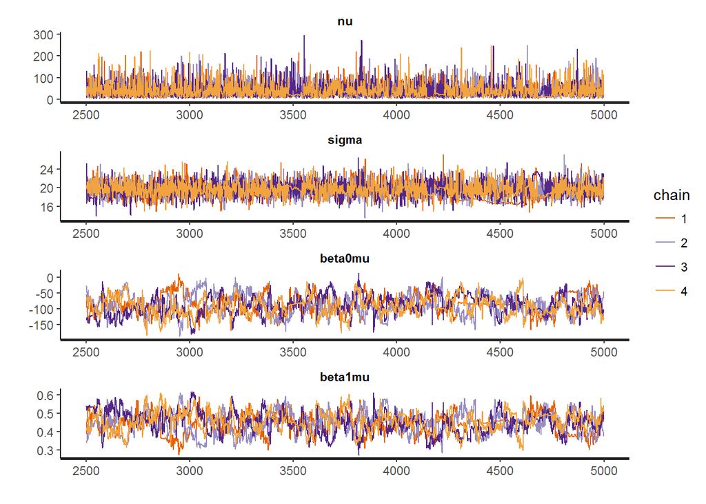

```r
rstan::traceplot(fit, ncol=1, inc_warmup=F,pars=c('nu', 'sigma', 'beta0mu', 'beta1mu'))
```

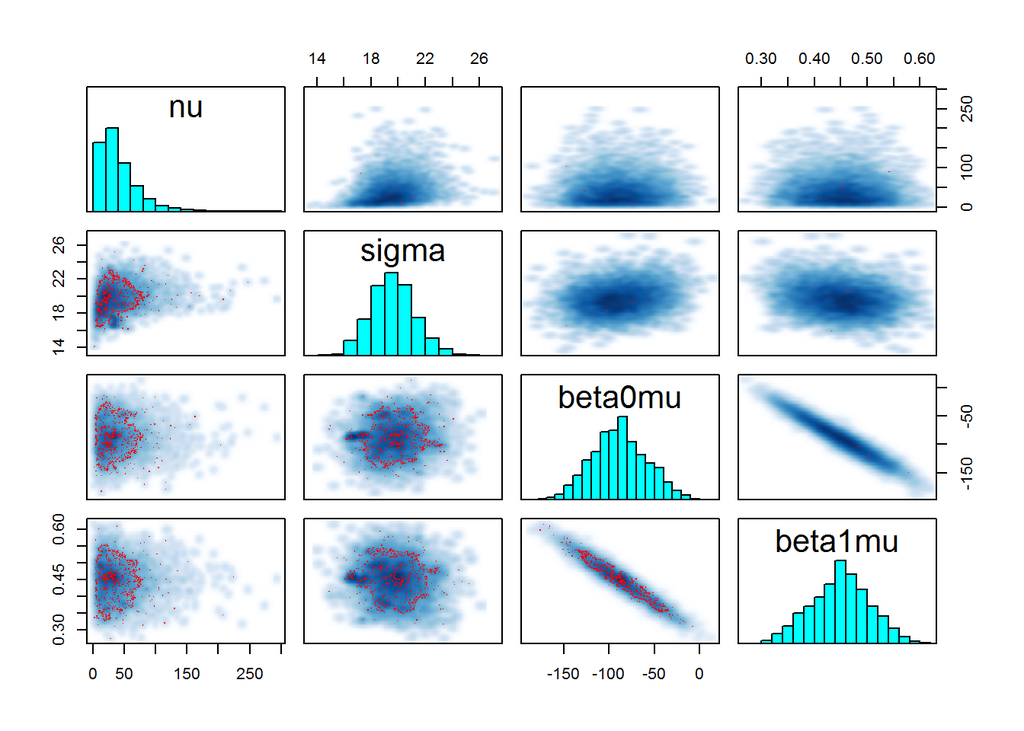

```r
pairs(fit, pars=c('nu', 'sigma', 'beta0mu', 'beta1mu'))
```

The pairs plot shows high correlation between $\beta_0$ and $\beta_1$ and the problematic points.  
By default, draws with below-median `accept_stat__` are plotted below the diagonal and those with above-median `accept_stat__` are plotted above the diagonal. Each off-diagonal square represents a bivariate distribution of the draws for the inter-section of the row-variable and the column-variable.  
Ideally, the below-diagonal intersection and the above-diagonal intersection of the same two variables should have distributions that are mirror images of each other.  
Any yellow points would indicate transitions where the maximum `treedepth__` was hit, and the red points indicate a transition where n_divergent__ = 1.  
Thus, the pairs plot should be used to get a sense of whether any sampling difficulties are occurring in the tails or near the mode.

```r
stan_ac(fit, separate_chains = T)
```

```
## 'pars' not specified. Showing first 10 parameters by default.
```

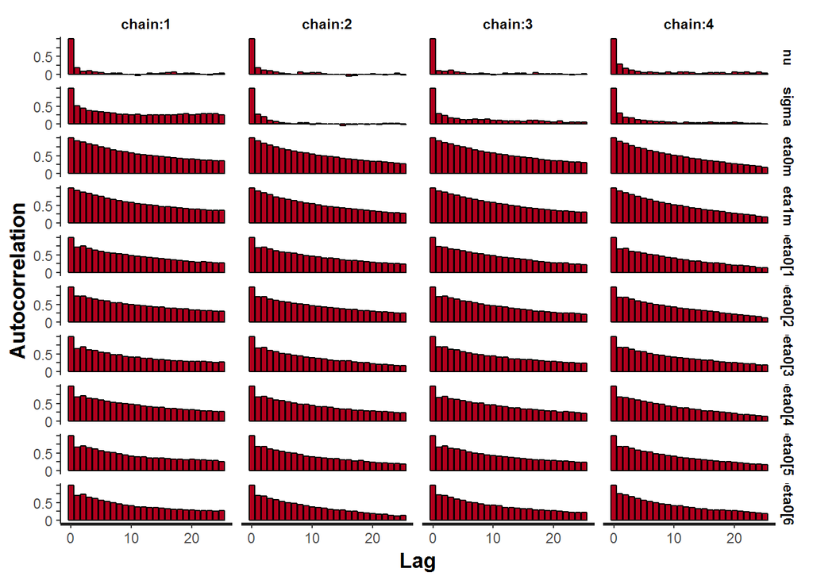

Very long memory in ACF.

Confirm high correlation between the parameters of lower level as well:

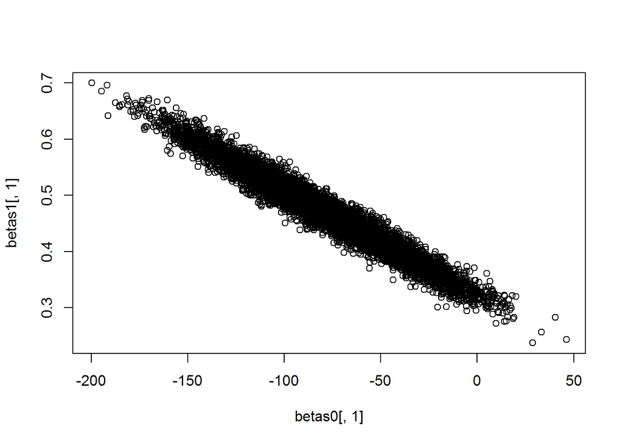

```r
betas0<-rstan::extract(fit,pars="beta0")$'beta0'
betas1<-rstan::extract(fit,pars="beta1")$'beta1'
plot(betas0[,1],betas1[,1])
```

### 5.1.5 Gaussian model

Because parameter $\nu$ of the robust fit indicated distribution very close to Gaussian, replace t-distribution with normal.

```r
modelString = "
data {
    int<lower=1> Ntotal;
    vector[Ntotal] y;
    vector[Ntotal] x;
    int<lower=1> Ngroups;
    int<lower=1, upper=Ngroups> group[Ntotal];
}
transformed data {
    real meanY;
    real sdY;
    vector[Ntotal] zy; // normalized y
    real meanX;
    real sdX;
    vector[Ntotal] zx; // normalized x
    meanY = mean(y);
    sdY = sd(y);
    zy = (y - meanY) / sdY;
    meanX = mean(x);
    sdX = sd(x);
    zx = (x - meanX) / sdX;
}
parameters {
    real<lower=0> zsigma;
//    real<lower=0> nu;
    real zbeta0mu;
    real zbeta1mu;
    real<lower=0> zbeta0sigma;
    real<lower=0> zbeta1sigma;
    vector[Ngroups] zbeta0;
    vector[Ngroups] zbeta1;
}
transformed parameters {
    real<lower=0> sigma;
    real beta0mu;
    real beta1mu;
    vector[Ngroups] beta0;
    vector[Ngroups] beta1;
    // Transform to original scale:
    sigma = zsigma * sdY;
    beta0mu = meanY + zbeta0mu * sdY  - zbeta1mu * meanX * sdY / sdX;
    beta1mu = zbeta1mu * sdY / sdX;
    beta0 = meanY + zbeta0 * sdY  - zbeta1 * meanX * sdY / sdX; // vectorized
    beta1 = zbeta1 * sdY / sdX;                                 // vectorized
}
model {
    zsigma ~ uniform(0.001, 1000);
//    nu ~ exponential(1/30.0);
    zbeta0mu ~ normal(0, 10.0);
    zbeta1mu ~ normal(0, 10.0);
    zbeta0sigma ~ uniform(0.001, 1000);
    zbeta1sigma ~ uniform(0.001, 1000);
    zbeta0 ~ normal(zbeta0mu, zbeta0sigma);  // vectorized
    zbeta1 ~ normal(zbeta1mu, zbeta1sigma);  // vectorized
    for (i in 1:Ntotal) {
        zy[i] ~ normal(zbeta0[group[i]] + zbeta1[group[i]] * x[i], zsigma);
    }
}
"
```

Run MCMC.

Run MCMC using one of the following ways: with or without corrections to the default parameters.

```r
stanModelNorm <- stan_model( model_code=modelString )
```

[output not shown]

```r
fit <- sampling (stanModelNorm,
                 data=dataList,
                 pars=c('sigma', 'beta0mu', 'beta1mu', 'beta0', 'beta1',
                        'zbeta0sigma', 'zbeta1sigma'),
                 iter=5000,
                 chains = 4, cores = 4
                 )
fit <- sampling (stanModelNorm,
                 data=dataList,
                 pars=c('sigma', 'beta0mu', 'beta1mu', 'beta0', 'beta1',
                        'zbeta0sigma', 'zbeta1sigma'),
                 iter=5000,
                 chains = 4, cores = 4,
                 control = list(adapt_delta = 0.9999, stepsize = 0.1, max_treedepth = 15)
                 )
```

```
## Warning: There were 170 divergent transitions after warmup. Increasing adapt_delta above 0.9999 may help. See
## http://mc-stan.org/misc/warnings.html#divergent-transitions-after-warmup
```

```
## Warning: There were 4 chains where the estimated Bayesian Fraction of Missing Information was low. See
## http://mc-stan.org/misc/warnings.html#bfmi-low
```

```
## Warning: Examine the pairs() plot to diagnose sampling problems
```

The first run creates warning similar to:

“Warning messages: 1: There were 1668 divergent transitions after warmup. Increasing adapt_delta above 0.8 may help. See http://mc-stan.org/misc/warnings.html#divergent-transitions-after-warmup 2: There were 1 chains where the estimated Bayesian Fraction of Missing Information was low. See http://mc-stan.org/misc/warnings.html#bfmi-low 3: Examine the pairs() plot to diagnose sampling problems”

Second run with adjusted parameters is an improvement, but still not good:

Save the fit.

```r
save(fit,file=paste(dataPath,"fitPanelStanNormal11152016.Rdata",sep="/"))
load(paste(dataPath,"fitPanelStanNormal11152016.Rdata",sep="/"))
```

Check the parameters of the fit.

```r
summary(do.call(rbind, args = get_sampler_params(fit, inc_warmup = TRUE)),digits = 2)
```

[output not shown]

```r
lapply(get_sampler_params(fit, inc_warmup = TRUE), summary, digits = 2)
```

```
## [[1]]
##  accept_stat__    stepsize__       treedepth__    n_leapfrog__
##  Min.   :0.00   Min.   :0.00055   Min.   : 0.0   Min.   :    1
##  1st Qu.:1.00   1st Qu.:0.01116   1st Qu.: 7.0   1st Qu.:  127
##  Median :1.00   Median :0.01116   Median : 8.0   Median :  255
##  Mean   :0.99   Mean   :0.01450   Mean   : 7.6   Mean   :  332
##  3rd Qu.:1.00   3rd Qu.:0.01546   3rd Qu.: 8.0   3rd Qu.:  255
##  Max.   :1.00   Max.   :1.15103   Max.   :13.0   Max.   :12287
##   divergent__       energy__
##  Min.   :0.000   Min.   : -137
##  1st Qu.:0.000   1st Qu.:  -77
##  Median :0.000   Median :  -66
##  Mean   :0.032   Mean   :  -40
##  3rd Qu.:0.000   3rd Qu.:  -58
##  Max.   :1.000   Max.   :75026
##
## [[2]]
##  accept_stat__    stepsize__      treedepth__    n_leapfrog__
##  Min.   :0.00   Min.   :0.0002   Min.   : 0.0   Min.   :    1
##  1st Qu.:1.00   1st Qu.:0.0041   1st Qu.: 7.8   1st Qu.:  255
##  Median :1.00   Median :0.0041   Median : 8.0   Median :  511
##  Mean   :0.99   Mean   :0.0106   Mean   : 8.4   Mean   :  573
##  3rd Qu.:1.00   3rd Qu.:0.0123   3rd Qu.: 9.0   3rd Qu.:  511
##  Max.   :1.00   Max.   :1.0462   Max.   :14.0   Max.   :24575
##   divergent__       energy__
##  Min.   :0.000   Min.   :  -137
##  1st Qu.:0.000   1st Qu.:   -76
##  Median :0.000   Median :   -66
##  Mean   :0.018   Mean   :    61
##  3rd Qu.:0.000   3rd Qu.:   -57
##  Max.   :1.000   Max.   :477827
##
## [[3]]
##  accept_stat__    stepsize__       treedepth__    n_leapfrog__
##  Min.   :0.00   Min.   :6.2e-05   Min.   : 0.0   Min.   :   1
##  1st Qu.:1.00   1st Qu.:1.1e-02   1st Qu.: 7.0   1st Qu.: 127
##  Median :1.00   Median :1.1e-02   Median : 8.0   Median : 255
##  Mean   :0.99   Mean   :1.5e-02   Mean   : 7.6   Mean   : 281
##  3rd Qu.:1.00   3rd Qu.:1.5e-02   3rd Qu.: 8.0   3rd Qu.: 255
##  Max.   :1.00   Max.   :1.4e+00   Max.   :13.0   Max.   :8191
```

[output cut: 8 more lines]

```
## [[4]]
##  accept_stat__    stepsize__       treedepth__    n_leapfrog__
##  Min.   :0.00   Min.   :0.00058   Min.   : 0.0   Min.   :   1
##  1st Qu.:1.00   1st Qu.:0.00887   1st Qu.: 7.0   1st Qu.: 127
##  Median :1.00   Median :0.00887   Median : 8.0   Median : 255
##  Mean   :0.99   Mean   :0.01466   Mean   : 7.7   Mean   : 324
##  3rd Qu.:1.00   3rd Qu.:0.01678   3rd Qu.: 8.0   3rd Qu.: 255
##  Max.   :1.00   Max.   :1.22305   Max.   :13.0   Max.   :8191
##   divergent__        energy__
##  Min.   :0.0000   Min.   : -148
##  1st Qu.:0.0000   1st Qu.:  -73
##  Median :0.0000   Median :  -64
##  Mean   :0.0098   Mean   :  -37
##  3rd Qu.:0.0000   3rd Qu.:  -56
##  Max.   :1.0000   Max.   :84404
```

Parameter `n_divergent__` is still higher than it should be.  
If parameter `treedepth__` has maximum greater than `max_treedepth` it is recommended to increase it.  
See [Stan vignette](https://cran.r-project.org/web/packages/rstan/vignettes/rstan_vignette.pdf) for more recommendations and interpretations.

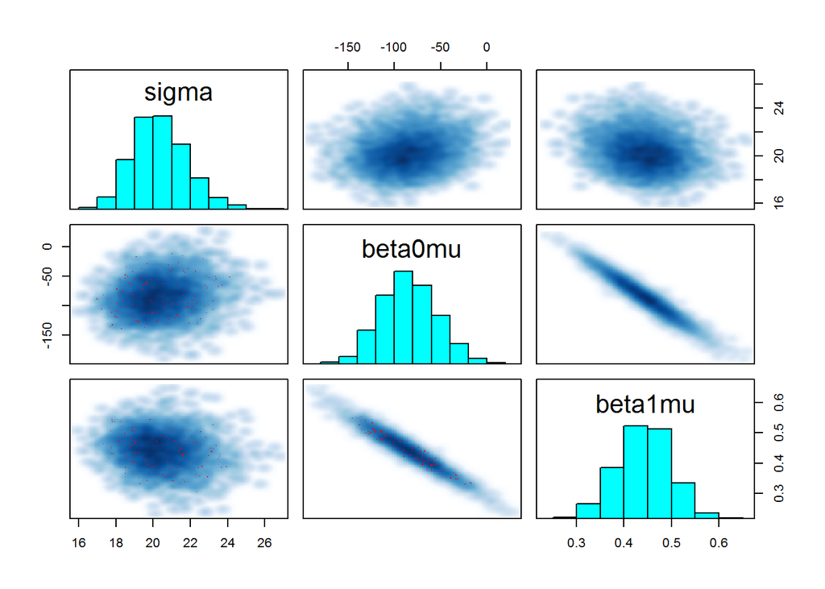

```r
pairs(fit, pars=c('sigma', 'beta0mu', 'beta1mu'))
```

Look at the results in `shinystan`.

```r
launch_shinystan(fit)
```

## 5.2 Example from Linear and Nonlinear Models

Example from Linear and Nonlinear Models (31010), lecture 9 considers results of Panel Study of Income Dynamics (PSID) that started in 1968.  
Example data `psid` show income per individual collected over number of years.  
The data are in package `faraway`.

```r
suppressMessages(library(faraway))
suppressMessages(library(lattice))
```

Plot the data for the first group of 20 particiants.

```r
data(psid)
head(psid)
```

```
##   age educ sex income year person
## 1  31   12   M   6000   68      1
## 2  31   12   M   5300   69      1
## 3  31   12   M   5200   70      1
## 4  31   12   M   6900   71      1
## 5  31   12   M   7500   72      1
## 6  31   12   M   8000   73      1
```

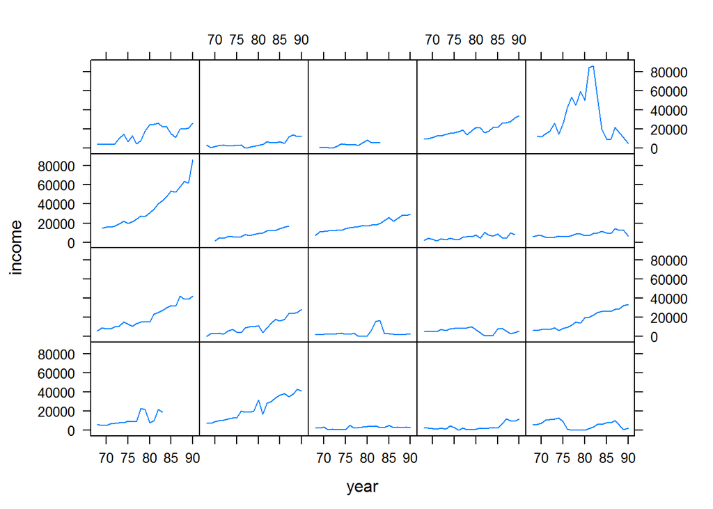

```r
xyplot(income ~ year | person, psid, type="l", subset=(person < 21),strip=FALSE)
```

Estimate slopes of log-incomes relative to time.  
Time interval is centered at 1978.

```r
slopes <- numeric(85);intercepts <- numeric(85)
for(i in 1:85){
lmod <- lm(log(income) ~ I(year-78), subset=(person==i), psid)
intercepts[i] <- coef(lmod)[1]
slopes[i] <- coef(lmod)[2]
}
head(cbind(slopes,intercepts))
```

```
##           slopes intercepts
## [1,]  0.08426670   9.399957
## [2,]  0.08281031   9.819091
## [3,]  0.03131149   7.893863
## [4,]  0.07585135   7.853027
## [5,] -0.04738677   8.033453
## [6,]  0.08953380   9.673443
```

Compare intercepts and slopes for males and females.

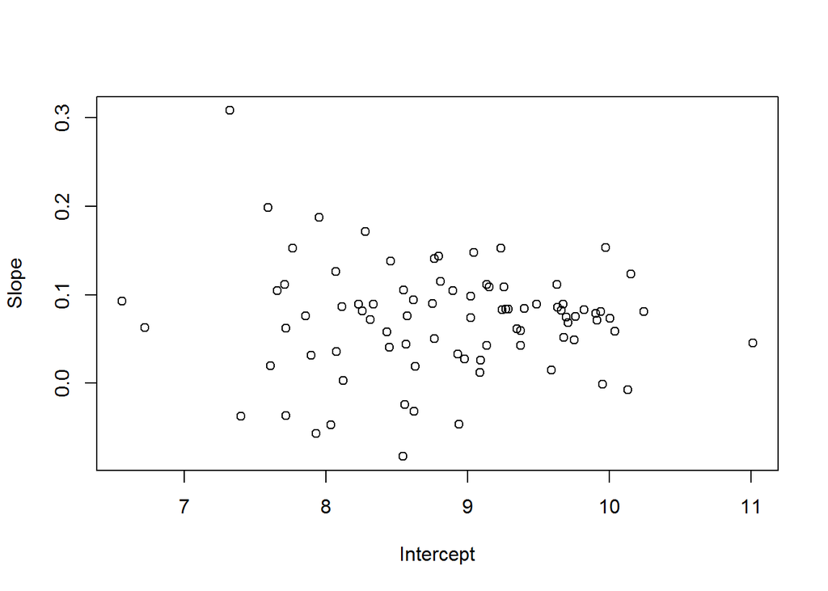

```r
plot(intercepts,slopes,xlab="Intercept",ylab="Slope")
```

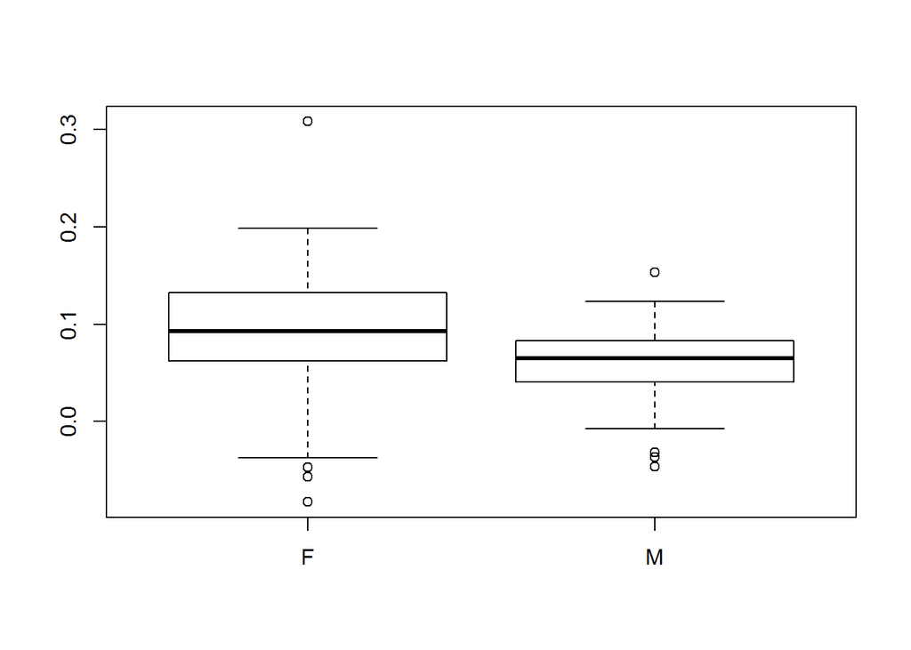

```r
psex <- psid$sex[match(1:85,psid$person)]
boxplot(split(slopes,psex))
```

Compare slopes for males and females.

```r
t.test(slopes[psex=="M"],slopes[psex=="F"])
```

```
##
##  Welch Two Sample t-test
##
## data:  slopes[psex == "M"] and slopes[psex == "F"]
## t = -2.3786, df = 56.736, p-value = 0.02077
## alternative hypothesis: true difference in means is not equal to 0
## 95 percent confidence interval:
##  -0.05916871 -0.00507729
## sample estimates:
##  mean of x  mean of y
## 0.05691046 0.08903346
```

Also compare incomes at the intercept.

```r
t.test(intercepts[psex=="M"],intercepts[psex=="F"])
```

```
##
##  Welch Two Sample t-test
##
## data:  intercepts[psex == "M"] and intercepts[psex == "F"]
## t = 8.2199, df = 79.719, p-value = 3.065e-12
## alternative hypothesis: true difference in means is not equal to 0
## 95 percent confidence interval:
##  0.8738792 1.4322218
## sample estimates:
## mean of x mean of y
##  9.382325  8.229275
```

Both gender differences appear to be significant at 5% level.  
For slopes advantage of females is not as unquestionable as advantage of males in intercepts.

Create subsets per gender group and analyze posterior distributions for slopes and intercepts.

```r
dfM<-subset(psid,sex=="M")[,c("year","income","person")]
dfF<-subset(psid,sex=="F")[,c("year","income","person")]
oldPersons<-unique(dfM$person)
newPersons<-match(dfM$person,oldPersons)
dfM$person<-newPersons
dataListM<-list(Ntotal=length(dfM$income),
               y=log(dfM$income),
               x=dfM$year-78,
               Ngroups = length(unique(dfM$person)),
               group = dfM$person
)
oldPersons<-unique(dfF$person)
newPersons<-match(dfF$person,oldPersons)
dfF$person<-newPersons
dataListF<-list(Ntotal=length(dfF$income),
               y=log(dfF$income),
               x=dfF$year-78,
               Ngroups = length(unique(dfF$person)),
               group = dfF$person
)
```

Create model description for fitting panel data seprately for females and males.  
Analyze differences in slopes and intercepts for individuals an for groups of two genders.

Run both models `fitF` and `fitM`separately.

[output not shown]

Check convergence of both models in `shiny_stan` (not shown).

```r
launch_shinystan(fitM)
launch_shinystan(fitF)
```

Explore the models.

Explore and interpret pairs of `nu`, `sigma`, `beta0mu`, `beta1mu` of each model.  
Plot HDI of parameters `beta0mu` and individual intercepts for each gender. Interpret them.  
Plot HDI of parameters `beta1mu` and individual slopes for each gender. Interpret them.

Create subsets of summaries with mean values and HDIs of both parameter sets.

```
##            M. mean     M. 2.5%   M. 97.5%    F. mean     F. 2.5%  F. 97.5%
## nu      0.38858804 0.180208031 0.63073646 0.19256062 0.028857040 0.4010056
## sigma   0.14044023 0.122935544 0.15870805 0.21621576 0.186471924 0.2498122
## beta0mu 9.51488022 9.357549776 9.66996571 8.50270336 8.294584835 8.7160375
## beta1mu 0.01138001 0.009737632 0.01297109 0.01208663 0.009415674 0.0147179
```

Compare intercepts and slopes of each gender groups obtained by `lm()` and by Bayesian approach.

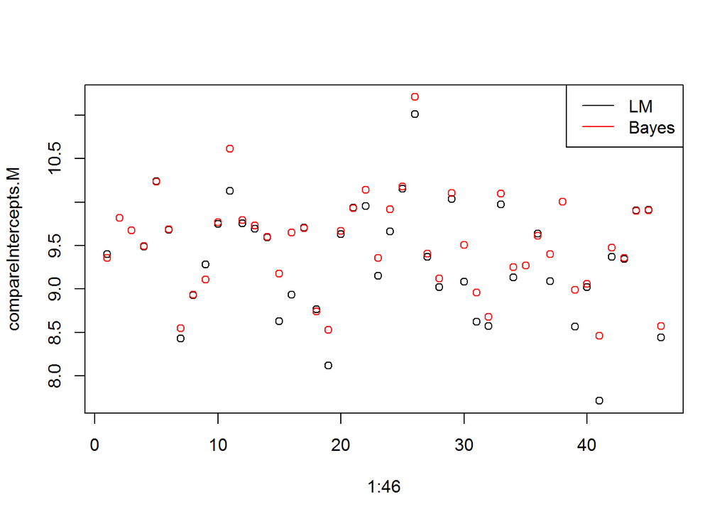

```r
compareIntercepts.M<-cbind(intercepts[psex=="M"],meanHDI.M[5:50,1])
compareSlopes.M<-cbind(slopes[psex=="M"],meanHDI.M[51:96,1])
matplot(1:46,compareIntercepts.M,type="p",pch=1)
legend("topright",legend=c("LM","Bayes"),col=c("black","red"),lty=1)
```

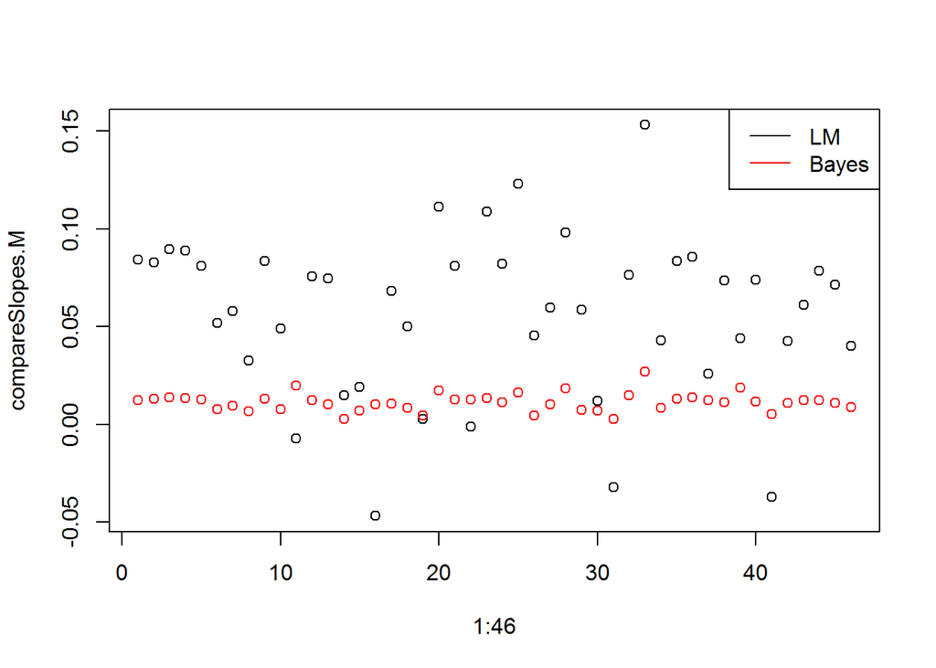

```r
matplot(1:46,compareSlopes.M,type="p",pch=1)
legend("topright",legend=c("LM","Bayes"),col=c("black","red"),lty=1)
```

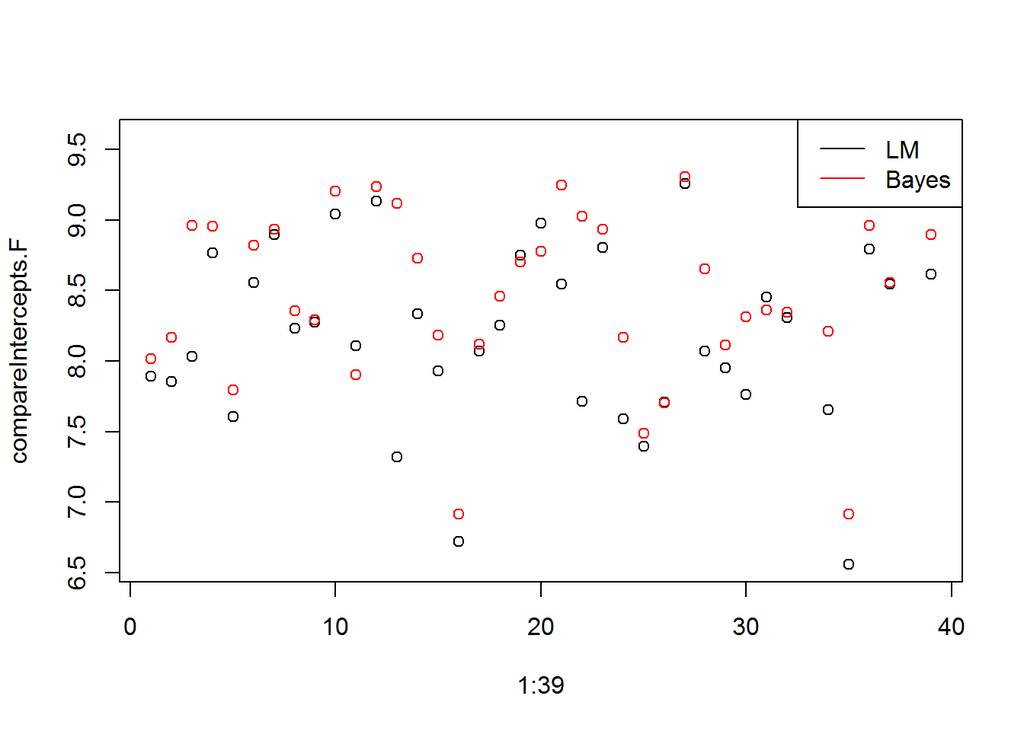

```r
compareIntercepts.F<-cbind(intercepts[psex=="F"],meanHDI.F[5:43,1])
compareSlopes.F<-cbind(slopes[psex=="F"],meanHDI.F[44:82,1])
matplot(1:39,compareIntercepts.F,type="p",pch=1)
legend("topright",legend=c("LM","Bayes"),col=c("black","red"),lty=1)
```

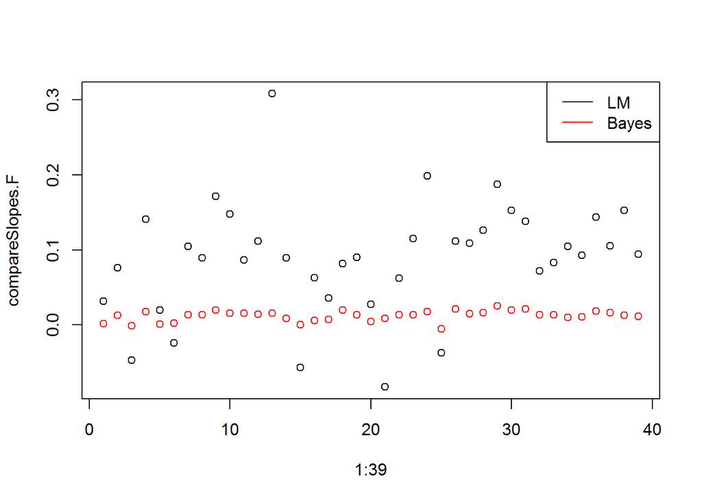

```r
matplot(1:39,compareSlopes.F,type="p",pch=1)
legend("topright",legend=c("LM","Bayes"),col=c("black","red"),lty=1)
```

Compare the group intercept and slope.

For Intercept:

```
##       2.5%    97.5%
## M 9.357550 9.669966
## F 8.294585 8.716038
```

For slope:

```
##          2.5%      97.5%
## M 0.009737632 0.01297109
## F 0.009415674 0.01471790
```